# HSS 317 Data Project Reproducibility Materials

Anthony Eryan, Kyle Rothwell, Savva Petrov

2024-05-10

# Gemini Function

The `gemini` function was created in order to utilize Google’s Gemini API for text generation and sentiment analysis. It takes several parameters, including `prompts`, `temperature`, `max_output_tokens`, `api_key`, and `model`. Here’s a breakdown of each parameter:

- `prompts`: A vector containing the text prompts for which sentiment analysis is to be performed.
- `temperature`: A parameter controlling the randomness of the text generation process. Higher values result in more random outputs.
- `max_output_tokens`: The maximum number of tokens in the generated text.
- `api_key`: The API key required for accessing the Gemini API. If not provided, the function prompts the user to input the API key.
- `model`: The name of the model to be used for text generation. Default is “gemini-pro”.

The function sends requests to the Gemini API, processes the responses, and returns the generated text along with sentiment analysis results. More information of the source code can be found [here](https://github.com/wilkflow/qssProj/blob/main/317_Gemini_LLM.R).

## Gemini Output Cleaning and Output Analysis

**Figure 1** *Stacked Crowdworker Sentiment Distribution (Crowdworkers vs Gemini Classification)*

```r
data <- read.csv("text_emotion_with_gemini.csv")
data = na.omit(data)

text_emotion <- read.csv("text_emotion_with_gemini.csv")
head(text_emotion) #optional: check the beginning of the dataset
```

```
##     tweet_id sentiment        author
## 1 1956967341     empty    xoshayzers
## 2 1956969456   neutral    feinyheiny
## 3 1956971981     worry andreagauster
## 4 1956974706      hate   MavrickAces
## 5 1956977084 happiness      ktierson
## 6 1956979894   neutral  lookitsholly
##                                                                                        content
## 1 @tiffanylue i know  i was listenin to bad habit earlier and i started freakin at his part =[
## 2                                                                             cant fall asleep
## 3       @raaaaaaek oh too bad! I hope it gets better. I've been having sleep issues lately too
## 4         It is so annoying when she starts typing on her computer in the middle of the night!
## 5                      mmm much better day... so far! it's still quite early. last day of #uds
## 6                          Chocolate milk is so much better through a straw. I lack said straw
##   gemini
## 1     12
## 2     11
## 3     10
## 4      1
## 5      6
## 6      2
```

```r
#remove all NA's to only analyze Gemini's performance
text_emotion_only_gemini <- na.omit(text_emotion)
head(text_emotion_only_gemini) #optional: verify that the dataset was cleaned
```

```
##     tweet_id sentiment        author
## 1 1956967341     empty    xoshayzers
## 2 1956969456   neutral    feinyheiny
## 3 1956971981     worry andreagauster
## 4 1956974706      hate   MavrickAces
## 5 1956977084 happiness      ktierson
## 6 1956979894   neutral  lookitsholly
##                                                                                        content
## 1 @tiffanylue i know  i was listenin to bad habit earlier and i started freakin at his part =[
## 2                                                                             cant fall asleep
## 3       @raaaaaaek oh too bad! I hope it gets better. I've been having sleep issues lately too
## 4         It is so annoying when she starts typing on her computer in the middle of the night!
## 5                      mmm much better day... so far! it's still quite early. last day of #uds
## 6                          Chocolate milk is so much better through a straw. I lack said straw
##   gemini
## 1     12
## 2     11
## 3     10
## 4      1
## 5      6
## 6      2
```

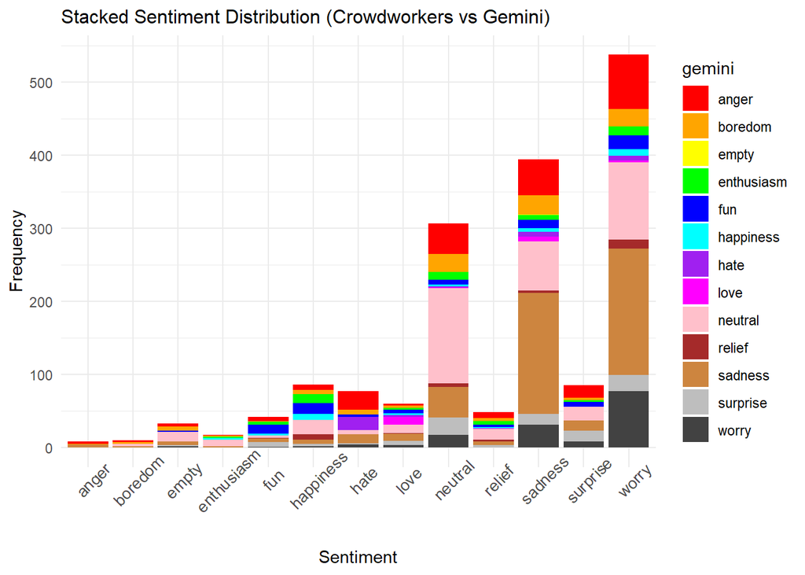

```r
# Define a function to map numeric values to sentiment words
map_sentiment <- function(value) {
  sentiment_map <- c("anger", "boredom", "empty", "enthusiasm", "fun",
                     "happiness", "hate", "love", "neutral", "relief",
                     "sadness", "surprise", "worry")
  return(sentiment_map[value])
}
data$gemini <- sapply(data$gemini, map_sentiment)

# Convert the numeric values in the gemini column to sentiment words
text_emotion_only_gemini$gemini <- sapply(text_emotion_only_gemini$gemini, map_sentiment)

#print(text_emotion_only_gemini)
# Optional: View the updated dataset
# Load required library for plotting
# Convert the sentiment_distribution data into a long format
library(tidyr)
library(ggplot2)
# Convert the rownames of sentiment_distribution to a new column
sentiment_distribution <- table(text_emotion_only_gemini$sentiment, text_emotion_only_gemini$gemini)
sentiment_distribution <- as.data.frame.matrix(sentiment_distribution)
sentiment_distribution$sentiment <- rownames(sentiment_distribution)

# Define custom colors for the bar plot
# Define breaks and labels for y-axis
breaks <- seq(0, 600, by = 100)
labels <- seq(0, 600, by = 100)
custom_colors <- c("red", "orange", "yellow", "green", "blue", "cyan", "purple", "magenta", "pink", "brown", "tan3", "gray", "gray26")
sentiment_long <- tidyr::pivot_longer(sentiment_distribution, cols = -sentiment, names_to = "gemini", values_to = "count")

# Create a stacked bar chart of sentiment distribution with custom colors
ggplot(sentiment_long, aes(x = sentiment, y = count, fill = gemini)) +
  geom_bar(stat = "identity",) +
  labs(title = "Stacked Sentiment Distribution (Crowdworkers vs Gemini)",
       x = "Sentiment",
       y = "Frequency") +
  scale_fill_manual(values = custom_colors) +  # Apply custom colors
  theme_minimal() +
  theme(axis.text.x = element_text(angle = 45, hjust = 0.5, size = 10), plot.title = element_text(size = 12, hjust = 0)) +
  scale_y_continuous(breaks = breaks, labels = labels) # Text adjustment for the x and y axis respectively
```

## Confusion Matrix and Heatmap: Crowdworkers vs Gemini

**Figure 2** *Confusion Matrix: Accuracy Between Gemini and Crowdworker Classification*

```r
 # Load necessary library
 library(caret)
 library(timechange)
```

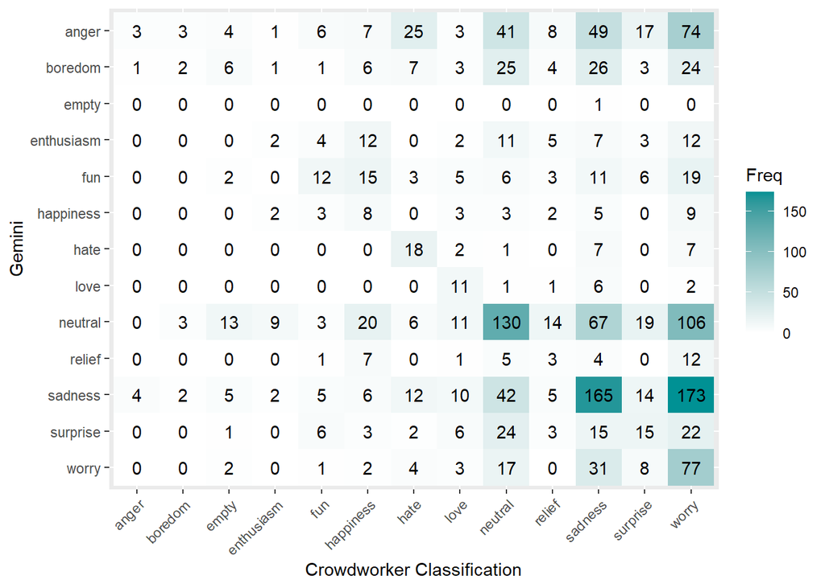

```r
 # Calculate confusion matrix
 c = confusionMatrix(as.factor(data$sentiment), as.factor(data$gemini), positive = NULL, dnn = c("Prediction", "Gemini"))
 # Convert confusion matrix to data frame
plt <- as.data.frame(c$table)
ggplot(plt, aes(Prediction, rev(Gemini), fill = Freq)) +
  geom_tile() +
  geom_text(aes(label = Freq)) +
  scale_fill_gradient(low = "white", high = "#009194") +
  labs(x = "Crowdworker Classification", y = "Gemini") +
  scale_x_discrete(labels = c("anger", "boredom", "empty", "enthusiasm", "fun",
                               "happiness", "hate", "love", "neutral", "relief",
                               "sadness", "surprise", "worry")) +
  scale_y_discrete(labels = rev(c("anger", "boredom", "empty", "enthusiasm", "fun",
                                   "happiness", "hate", "love", "neutral", "relief",
                                   "sadness", "surprise", "worry"))) +
  theme(axis.text.x = element_text(angle = 45, hjust = 1))
```

**Figure 2.5** *Confusion matrix output*

```r
print(c[3])
```

```
## $overall
##       Accuracy          Kappa  AccuracyLower  AccuracyUpper   AccuracyNull
##      0.2618908      0.1437429      0.2411405      0.2834647      0.2613036
## AccuracyPValue  McnemarPValue
##      0.4872510            NaN
```

**Figure 3** *Crowdworker Sentiment Classification: Distribution of Sentiments*

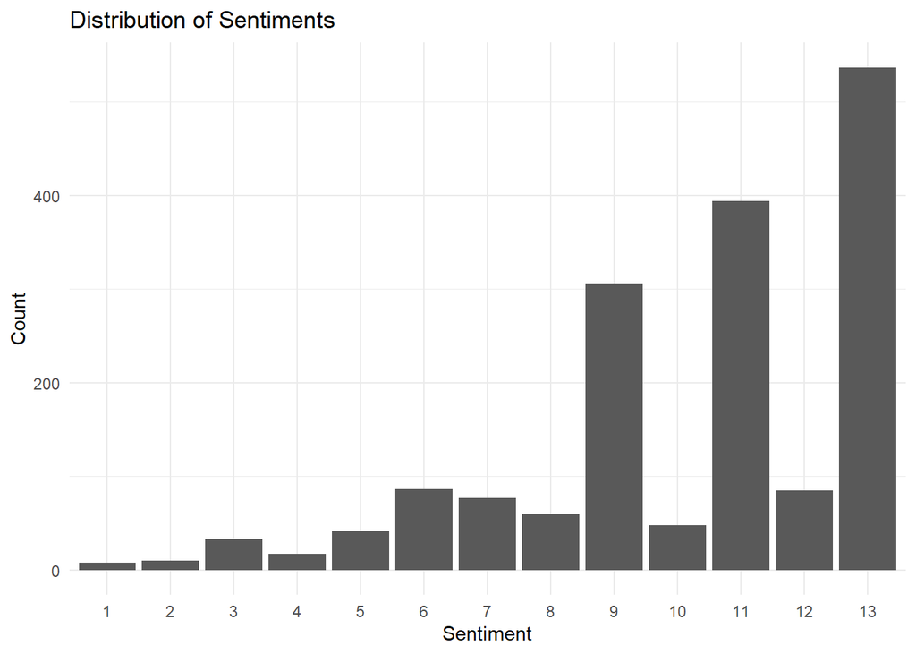

```r
# Define the mapping of sentiment labels to numeric values
sentiment_mapping <- c('anger' = 1, 'boredom' = 2, 'empty' = 3, 'enthusiasm' = 4,
                       'fun' = 5, 'happiness' = 6, 'hate' = 7, 'love' = 8,
                       'neutral' = 9, 'relief' = 10, 'sadness' = 11, 'surprise' = 12,
                       'worry' = 13)
# Convert sentiment labels to numeric values
data$sentiment <- as.integer(factor(data$sentiment, levels = names(sentiment_mapping), labels = sentiment_mapping))
# Count the occurrences of each sentiment
sentiment_counts <- table(data$sentiment)
# Create a bar plot of sentiment distribution
ggplot(data, aes(x=factor(sentiment, levels = names(sentiment_counts)))) +
  geom_bar() +
  labs(x = "Sentiment", y = "Count", title = "Distribution of Sentiments") +
  theme_minimal()
```

**Figure 4** *Gemini Sentiment Classification: Distribution of Sentiments*

```r
# Optional: Display the structure and first few rows of the data
head(data)
```

```
##     tweet_id sentiment        author
## 1 1956967341         3    xoshayzers
## 2 1956969456         9    feinyheiny
## 3 1956971981        13 andreagauster
## 4 1956974706         7   MavrickAces
## 5 1956977084         6      ktierson
## 6 1956979894         9  lookitsholly
##                                                                                        content
## 1 @tiffanylue i know  i was listenin to bad habit earlier and i started freakin at his part =[
## 2                                                                             cant fall asleep
## 3       @raaaaaaek oh too bad! I hope it gets better. I've been having sleep issues lately too
## 4         It is so annoying when she starts typing on her computer in the middle of the night!
## 5                      mmm much better day... so far! it's still quite early. last day of #uds
## 6                          Chocolate milk is so much better through a straw. I lack said straw
##      gemini
## 1  surprise
## 2   sadness
## 3    relief
## 4     anger
## 5 happiness
## 6   boredom
```

```r
str(data)
```

```
## 'data.frame':    1703 obs. of  5 variables:
##  $ tweet_id : int  1956967341 1956969456 1956971981 1956974706 1956977084 1956979894 1956982449 1956983931 1956985764 1956988145 ...
##  $ sentiment: int  3 9 13 7 6 9 13 9 11 9 ...
##  $ author   : chr  "xoshayzers" "feinyheiny" "andreagauster" "MavrickAces" ...
##  $ content  : chr  "@tiffanylue i know  i was listenin to bad habit earlier and i started freakin at his part =[" "cant fall asleep" "@raaaaaaek oh too bad! I hope it gets better. I've been having sleep issues lately too" "It is so annoying when she starts typing on her computer in the middle of …
##  $ gemini   : chr  "surprise" "sadness" "relief" "anger" ...
##  - attr(*, "na.action")= 'omit' Named int [1:54] 43 65 83 143 153 165 193 200 223 297 ...
##   ..- attr(*, "names")= chr [1:54] "43" "65" "83" "143" ...
```

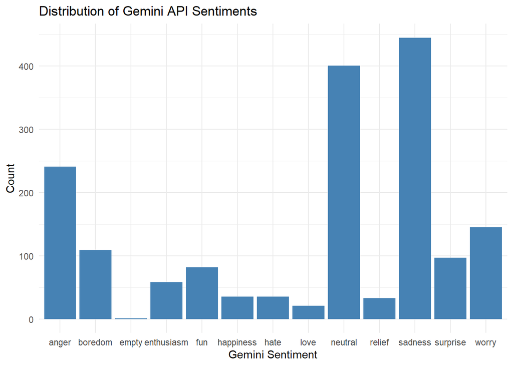

```r
# Count the occurrences of each Gemini sentiment
gemini_counts <- table(data$gemini)

ggplot(data, aes(x=factor(gemini, levels = names(gemini_counts)))) +
  geom_bar(fill = "steelblue") +
  labs(x = "Gemini Sentiment", y = "Count", title = "Distribution of Gemini API Sentiments") +
  theme_minimal()
```

**Figure 5** *Gemini vs Crowdworker Sentiment Classification: Distribution of Sentiments*

```r
# Load necessary packages
library(dplyr)
```

[figure not shown]

```r
library(ggplot2)

# Read the data and remove NAs (Tweets that were not queried)
data <- read.csv("text_emotion_with_gemini.csv")
data = na.omit(data)
sentiment_mapping <- c('anger' = 1, 'boredom' = 2, 'empty' = 3, 'enthusiasm' = 4,
                       'fun' = 5, 'happiness' = 6, 'hate' = 7, 'love' = 8,
                       'neutral' = 9, 'relief' = 10, 'sadness' = 11, 'surprise' = 12,
                       'worry' = 13)
# Convert sentiment labels to numeric values
data$sentiment <- as.integer(factor(data$sentiment, levels = names(sentiment_mapping), labels = sentiment_mapping))
# Count the occurrences of each sentiment for both crowdworker and Gemini classifications
original_counts <- data %>%
  count(sentiment, name = "original_count")
gemini_counts <- data %>%
  count(gemini, name = "gemini_count")
# Define levels of sentiment for plotting
levels_sentiment <- sort(as.numeric(unique(c(as.character(original_counts$sentiment), as.character(gemini_counts$gemini)))))
levels_sentiment <- as.character(levels_sentiment)
levels_sentiment[is.na(levels_sentiment)] <- "NA"
# Set sentiment factors with defined levels
original_counts$sentiment <- factor(original_counts$sentiment, levels = levels_sentiment)
gemini_counts$gemini <- factor(gemini_counts$gemini, levels = levels_sentiment)
# Merge counts of crowdworker and Gemini sentiments
combined_counts <- full_join(original_counts, gemini_counts, by = c("sentiment" = "gemini"))
# Pivot the data to long format for plotting
plot_data <- tidyr::pivot_longer(combined_counts, cols = c("original_count", "gemini_count"),
                                 names_to = "Classification", values_to = "count")
plot_data$count[is.na(plot_data$count)] <- 0
# Create a bar plot comparing crowdworker and Gemini sentiment counts

ggplot(plot_data, aes(x = sentiment, y = count, fill = Classification)) +
  geom_bar(stat = "identity", position = position_dodge(width = 0.7), width = 0.6) +
  scale_fill_manual(values = c("original_count" = "blue", "gemini_count" = "red")) +
  labs(x = "Sentiment", y = "Count", title = "Comparison of Crowdworker and Gemini Sentiment Counts") +
  theme_minimal()
```

## Chi-Squared Test

```r
# Convert gemini and sentiment variables to factors
data$gemini <- factor(data$gemini)
data$sentiment <- as.factor(data$sentiment)
# Create a contingency table to summarize the relationship between Gemini and sentiment
table_data <- table(data$gemini, data$sentiment)
# Perform Chi-Squared Test to evaluate the independence between Gemini and sentiment
chi_squared_result <- chisq.test(table_data)
# Display the Chi-Squared Test results
chi_squared_result
```

```
##
##  Pearson's Chi-squared test
##
## data:  table_data
## X-squared = 870.63, df = 144, p-value < 2.2e-16
```